# Risk Factor Analysis

## Outcome Variable

**Outcome Variable:** sstunted

## Predictor Variables

**Intervention Variable:** perdiar6

**Adjustment Set:**

unadjusted

## Stratifying Variables

The analysis was stratified on these variable(s):

- agecat
- studyid
- country

## Data Summary

| agecat | studyid | country | perdiar6 | sstunted | n_cell | n |
| --- | --- | --- | --- | --- | --- | --- |
| Birth | CMIN | BANGLADESH | 0% | 0 | 10 | 26 |
| Birth | CMIN | BANGLADESH | 0% | 1 | 6 | 26 |
| Birth | CMIN | BANGLADESH | (0%, 5%] | 0 | 4 | 26 |
| Birth | CMIN | BANGLADESH | (0%, 5%] | 1 | 0 | 26 |
| Birth | CMIN | BANGLADESH | >5% | 0 | 6 | 26 |
| Birth | CMIN | BANGLADESH | >5% | 1 | 0 | 26 |
| Birth | CONTENT | PERU | 0% | 0 | 0 | 2 |
| Birth | CONTENT | PERU | 0% | 1 | 0 | 2 |
| Birth | CONTENT | PERU | (0%, 5%] | 0 | 1 | 2 |
| Birth | CONTENT | PERU | (0%, 5%] | 1 | 0 | 2 |
| Birth | CONTENT | PERU | >5% | 0 | 1 | 2 |
| Birth | CONTENT | PERU | >5% | 1 | 0 | 2 |
| Birth | EE | PAKISTAN | 0% | 0 | 179 | 240 |
| Birth | EE | PAKISTAN | 0% | 1 | 44 | 240 |
| Birth | EE | PAKISTAN | (0%, 5%] | 0 | 11 | 240 |
| Birth | EE | PAKISTAN | (0%, 5%] | 1 | 4 | 240 |
| Birth | EE | PAKISTAN | >5% | 0 | 2 | 240 |
| Birth | EE | PAKISTAN | >5% | 1 | 0 | 240 |
| Birth | MAL-ED | BANGLADESH | 0% | 0 | 69 | 231 |
| Birth | MAL-ED | BANGLADESH | 0% | 1 | 3 | 231 |
| Birth | MAL-ED | BANGLADESH | (0%, 5%] | 0 | 87 | 231 |
| Birth | MAL-ED | BANGLADESH | (0%, 5%] | 1 | 3 | 231 |
| Birth | MAL-ED | BANGLADESH | >5% | 0 | 66 | 231 |
| Birth | MAL-ED | BANGLADESH | >5% | 1 | 3 | 231 |
| Birth | MAL-ED | BRAZIL | 0% | 0 | 54 | 65 |
| Birth | MAL-ED | BRAZIL | 0% | 1 | 3 | 65 |
| Birth | MAL-ED | BRAZIL | (0%, 5%] | 0 | 6 | 65 |
| Birth | MAL-ED | BRAZIL | (0%, 5%] | 1 | 0 | 65 |
| Birth | MAL-ED | BRAZIL | >5% | 0 | 2 | 65 |
| Birth | MAL-ED | BRAZIL | >5% | 1 | 0 | 65 |

[output cut: 204 more lines]

The following strata were considered:

- agecat: 24 months, studyid: CMIN, country: BANGLADESH
- agecat: 24 months, studyid: CONTENT, country: PERU
- agecat: 24 months, studyid: EE, country: PAKISTAN
- agecat: 24 months, studyid: MAL-ED, country: BANGLADESH
- agecat: 24 months, studyid: MAL-ED, country: BRAZIL
- agecat: 24 months, studyid: MAL-ED, country: INDIA
- agecat: 24 months, studyid: MAL-ED, country: NEPAL
- agecat: 24 months, studyid: MAL-ED, country: PERU
- agecat: 24 months, studyid: MAL-ED, country: SOUTH AFRICA
- agecat: 24 months, studyid: MAL-ED, country: TANZANIA, UNITED REPUBLIC OF
- agecat: 24 months, studyid: NIH-Birth, country: BANGLADESH
- agecat: 24 months, studyid: NIH-Crypto, country: BANGLADESH
- agecat: 24 months, studyid: PROVIDE, country: BANGLADESH
- agecat: 6 months, studyid: CMIN, country: BANGLADESH
- agecat: 6 months, studyid: CONTENT, country: PERU
- agecat: 6 months, studyid: EE, country: PAKISTAN
- agecat: 6 months, studyid: MAL-ED, country: BANGLADESH
- agecat: 6 months, studyid: MAL-ED, country: BRAZIL
- agecat: 6 months, studyid: MAL-ED, country: INDIA
- agecat: 6 months, studyid: MAL-ED, country: NEPAL
- agecat: 6 months, studyid: MAL-ED, country: PERU
- agecat: 6 months, studyid: MAL-ED, country: SOUTH AFRICA
- agecat: 6 months, studyid: MAL-ED, country: TANZANIA, UNITED REPUBLIC OF
- agecat: 6 months, studyid: NIH-Birth, country: BANGLADESH
- agecat: 6 months, studyid: NIH-Crypto, country: BANGLADESH
- agecat: 6 months, studyid: PROVIDE, country: BANGLADESH
- agecat: Birth, studyid: CMIN, country: BANGLADESH
- agecat: Birth, studyid: CONTENT, country: PERU
- agecat: Birth, studyid: EE, country: PAKISTAN
- agecat: Birth, studyid: MAL-ED, country: BANGLADESH
- agecat: Birth, studyid: MAL-ED, country: BRAZIL
- agecat: Birth, studyid: MAL-ED, country: INDIA
- agecat: Birth, studyid: MAL-ED, country: NEPAL
- agecat: Birth, studyid: MAL-ED, country: PERU
- agecat: Birth, studyid: MAL-ED, country: SOUTH AFRICA
- agecat: Birth, studyid: MAL-ED, country: TANZANIA, UNITED REPUBLIC OF
- agecat: Birth, studyid: NIH-Birth, country: BANGLADESH
- agecat: Birth, studyid: NIH-Crypto, country: BANGLADESH
- agecat: Birth, studyid: PROVIDE, country: BANGLADESH

### Dropped Strata

Some strata were dropped due to rare outcomes:

- agecat: Birth, studyid: CMIN, country: BANGLADESH
- agecat: Birth, studyid: CONTENT, country: PERU
- agecat: Birth, studyid: EE, country: PAKISTAN
- agecat: Birth, studyid: MAL-ED, country: BANGLADESH
- agecat: Birth, studyid: MAL-ED, country: BRAZIL
- agecat: Birth, studyid: MAL-ED, country: INDIA
- agecat: Birth, studyid: MAL-ED, country: NEPAL
- agecat: Birth, studyid: MAL-ED, country: PERU
- agecat: Birth, studyid: MAL-ED, country: SOUTH AFRICA
- agecat: Birth, studyid: MAL-ED, country: TANZANIA, UNITED REPUBLIC OF
- agecat: Birth, studyid: NIH-Birth, country: BANGLADESH
- agecat: Birth, studyid: NIH-Crypto, country: BANGLADESH
- agecat: Birth, studyid: PROVIDE, country: BANGLADESH
- agecat: 6 months, studyid: CONTENT, country: PERU
- agecat: 6 months, studyid: EE, country: PAKISTAN
- agecat: 6 months, studyid: MAL-ED, country: BANGLADESH
- agecat: 6 months, studyid: MAL-ED, country: BRAZIL
- agecat: 6 months, studyid: MAL-ED, country: INDIA
- agecat: 6 months, studyid: MAL-ED, country: NEPAL
- agecat: 6 months, studyid: MAL-ED, country: PERU
- agecat: 6 months, studyid: MAL-ED, country: SOUTH AFRICA
- agecat: 6 months, studyid: MAL-ED, country: TANZANIA, UNITED REPUBLIC OF
- agecat: 6 months, studyid: PROVIDE, country: BANGLADESH
- agecat: 24 months, studyid: CONTENT, country: PERU
- agecat: 24 months, studyid: EE, country: PAKISTAN
- agecat: 24 months, studyid: MAL-ED, country: BRAZIL
- agecat: 24 months, studyid: MAL-ED, country: NEPAL
- agecat: 24 months, studyid: MAL-ED, country: PERU
- agecat: 24 months, studyid: MAL-ED, country: SOUTH AFRICA

## Methods Detail

We’re interested in the causal parameters $E[Y_a]$ for all values of $a \in \mathcal{A}$. These parameters represent the mean outcome if, possibly contrary to fact, we intervened to set all units to have $A=a$. Under the randomization and positivity assumptions, these are identified by the statistical parameters $\psi_a=E_W[E_{Y|A,W}(Y|A=a,W)]$. In addition, we’re interested in the mean of $Y$, $E[Y]$ under no intervention (the observed mean). We will estimate these parameters by using SuperLearner to fit the relevant likelihood factors – $E_{Y|A,W}(Y|A=a,W)$ and $p(A=a|W)$, and then updating our likelihood fit using a joint TMLE.

For unadjusted analyses ($W=\{\}$), initial likelihoods were estimated using Lrnr_glm to estimate the simple $E(Y|A)$ and Lrnr_mean to estimate $p(A)$. For adjusted analyses, a small library containing Lrnr_glmnet, Lrnr_xgboost, and Lrnr_mean was used.

Having estimated these parameters, we will then use the delta method to estimate relative risks and attributable risks relative to a prespecified baseline level of $A$.

# Results Detail

## Results Plots

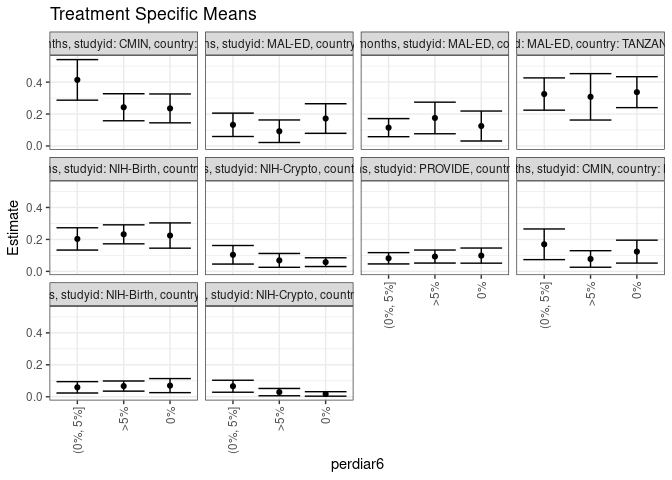

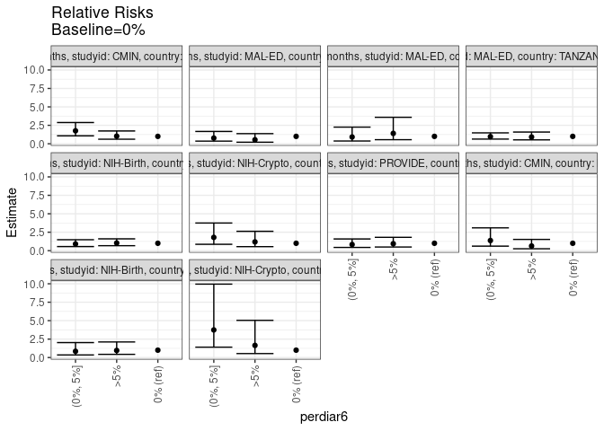

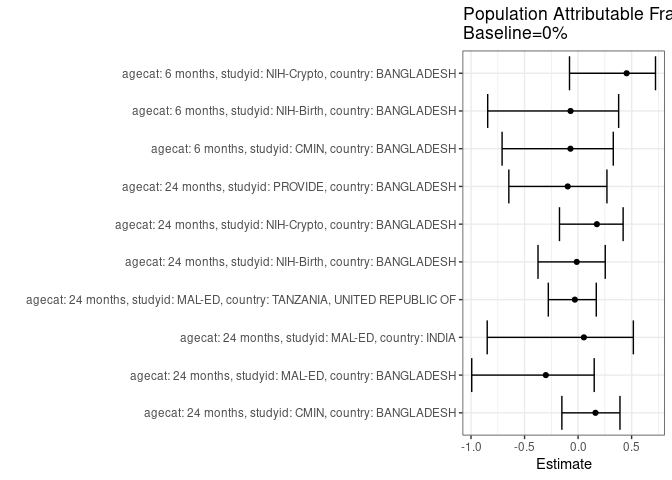

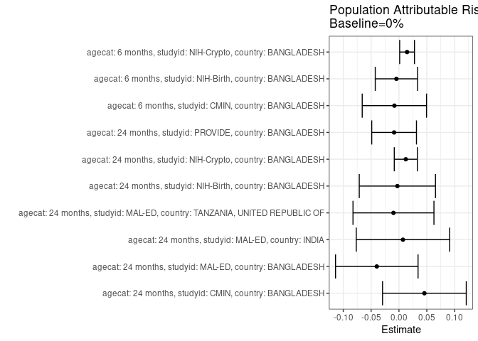

## Results Table

### Parameter: TSM

| agecat | studyid | country | intervention_level | baseline_level | estimate | ci_lower | ci_upper |
| --- | --- | --- | --- | --- | --- | --- | --- |
| 6 months | CMIN | BANGLADESH | 0% | NA | 0.1234568 | 0.0516699 | 0.1952437 |
| 6 months | CMIN | BANGLADESH | (0%, 5%] | NA | 0.1694915 | 0.0735595 | 0.2654235 |
| 6 months | CMIN | BANGLADESH | >5% | NA | 0.0776699 | 0.0258741 | 0.1294657 |
| 6 months | NIH-Birth | BANGLADESH | 0% | NA | 0.0697674 | 0.0257647 | 0.1137702 |
| 6 months | NIH-Birth | BANGLADESH | (0%, 5%] | NA | 0.0591716 | 0.0235657 | 0.0947774 |
| 6 months | NIH-Birth | BANGLADESH | >5% | NA | 0.0669456 | 0.0352303 | 0.0986609 |
| 6 months | NIH-Crypto | BANGLADESH | 0% | NA | 0.0175953 | 0.0036310 | 0.0315596 |
| 6 months | NIH-Crypto | BANGLADESH | (0%, 5%] | NA | 0.0658683 | 0.0282208 | 0.1035157 |
| 6 months | NIH-Crypto | BANGLADESH | >5% | NA | 0.0289855 | 0.0061153 | 0.0518557 |
| 24 months | CMIN | BANGLADESH | 0% | NA | 0.2352941 | 0.1449311 | 0.3256571 |
| 24 months | CMIN | BANGLADESH | (0%, 5%] | NA | 0.4137931 | 0.2867795 | 0.5408067 |
| 24 months | CMIN | BANGLADESH | >5% | NA | 0.2424242 | 0.1578320 | 0.3270165 |
| 24 months | MAL-ED | BANGLADESH | 0% | NA | 0.1718750 | 0.0792263 | 0.2645237 |
| 24 months | MAL-ED | BANGLADESH | (0%, 5%] | NA | 0.1325301 | 0.0594128 | 0.2056474 |
| 24 months | MAL-ED | BANGLADESH | >5% | NA | 0.0923077 | 0.0217724 | 0.1628430 |
| 24 months | MAL-ED | INDIA | 0% | NA | 0.1250000 | 0.0312340 | 0.2187660 |
| 24 months | MAL-ED | INDIA | (0%, 5%] | NA | 0.1147541 | 0.0580724 | 0.1714358 |
| 24 months | MAL-ED | INDIA | >5% | NA | 0.1754386 | 0.0764823 | 0.2743949 |
| 24 months | MAL-ED | TANZANIA, UNITED REPUBLIC OF | 0% | NA | 0.3369565 | 0.2401445 | 0.4337685 |
| 24 months | MAL-ED | TANZANIA, UNITED REPUBLIC OF | (0%, 5%] | NA | 0.3253012 | 0.2242774 | 0.4263251 |
| 24 months | MAL-ED | TANZANIA, UNITED REPUBLIC OF | >5% | NA | 0.3076923 | 0.1625009 | 0.4528837 |
| 24 months | NIH-Birth | BANGLADESH | 0% | NA | 0.2242991 | 0.1451722 | 0.3034259 |
| 24 months | NIH-Birth | BANGLADESH | (0%, 5%] | NA | 0.2031250 | 0.1333457 | 0.2729043 |
| 24 months | NIH-Birth | BANGLADESH | >5% | NA | 0.2319588 | 0.1724951 | 0.2914224 |
| 24 months | NIH-Crypto | BANGLADESH | 0% | NA | 0.0577617 | 0.0302618 | 0.0852617 |
| 24 months | NIH-Crypto | BANGLADESH | (0%, 5%] | NA | 0.1037736 | 0.0456610 | 0.1618862 |
| 24 months | NIH-Crypto | BANGLADESH | >5% | NA | 0.0687023 | 0.0253447 | 0.1120599 |
| 24 months | PROVIDE | BANGLADESH | 0% | NA | 0.0986842 | 0.0512311 | 0.1461373 |
| 24 months | PROVIDE | BANGLADESH | (0%, 5%] | NA | 0.0818966 | 0.0465816 | 0.1172115 |
| 24 months | PROVIDE | BANGLADESH | >5% | NA | 0.0927835 | 0.0519220 | 0.1336450 |

### Parameter: E(Y)

| agecat | studyid | country | intervention_level | baseline_level | estimate | ci_lower | ci_upper |
| --- | --- | --- | --- | --- | --- | --- | --- |
| 6 months | CMIN | BANGLADESH | NA | NA | 0.1152263 | 0.0749980 | 0.1554547 |
| 6 months | NIH-Birth | BANGLADESH | NA | NA | 0.0651769 | 0.0442802 | 0.0860736 |
| 6 months | NIH-Crypto | BANGLADESH | NA | NA | 0.0321678 | 0.0192256 | 0.0451101 |
| 24 months | CMIN | BANGLADESH | NA | NA | 0.2809917 | 0.2242434 | 0.3377401 |
| 24 months | MAL-ED | BANGLADESH | NA | NA | 0.1320755 | 0.0863920 | 0.1777589 |
| 24 months | MAL-ED | INDIA | NA | NA | 0.1321586 | 0.0880054 | 0.1763117 |
| 24 months | MAL-ED | TANZANIA, UNITED REPUBLIC OF | NA | NA | 0.3271028 | 0.2640978 | 0.3901078 |
| 24 months | NIH-Birth | BANGLADESH | NA | NA | 0.2214452 | 0.1821080 | 0.2607825 |
| 24 months | NIH-Crypto | BANGLADESH | NA | NA | 0.0700389 | 0.0479542 | 0.0921236 |
| 24 months | PROVIDE | BANGLADESH | NA | NA | 0.0899654 | 0.0666186 | 0.1133122 |

### Parameter: RR

| agecat | studyid | country | intervention_level | baseline_level | estimate | ci_lower | ci_upper |
| --- | --- | --- | --- | --- | --- | --- | --- |
| 6 months | CMIN | BANGLADESH | 0% | 0% | 1.0000000 | 1.0000000 | 1.000000 |
| 6 months | CMIN | BANGLADESH | (0%, 5%] | 0% | 1.3728814 | 0.6098466 | 3.090619 |
| 6 months | CMIN | BANGLADESH | >5% | 0% | 0.6291262 | 0.2597075 | 1.524022 |
| 6 months | NIH-Birth | BANGLADESH | 0% | 0% | 1.0000000 | 1.0000000 | 1.000000 |
| 6 months | NIH-Birth | BANGLADESH | (0%, 5%] | 0% | 0.8481262 | 0.3547163 | 2.027869 |
| 6 months | NIH-Birth | BANGLADESH | >5% | 0% | 0.9595537 | 0.4360054 | 2.111770 |
| 6 months | NIH-Crypto | BANGLADESH | 0% | 0% | 1.0000000 | 1.0000000 | 1.000000 |
| 6 months | NIH-Crypto | BANGLADESH | (0%, 5%] | 0% | 3.7435130 | 1.4077570 | 9.954765 |
| 6 months | NIH-Crypto | BANGLADESH | >5% | 0% | 1.6473430 | 0.5379715 | 5.044392 |
| 24 months | CMIN | BANGLADESH | 0% | 0% | 1.0000000 | 1.0000000 | 1.000000 |
| 24 months | CMIN | BANGLADESH | (0%, 5%] | 0% | 1.7586207 | 1.0756153 | 2.875328 |
| 24 months | CMIN | BANGLADESH | >5% | 0% | 1.0303030 | 0.6132147 | 1.731081 |
| 24 months | MAL-ED | BANGLADESH | 0% | 0% | 1.0000000 | 1.0000000 | 1.000000 |
| 24 months | MAL-ED | BANGLADESH | (0%, 5%] | 0% | 0.7710843 | 0.3565481 | 1.667576 |
| 24 months | MAL-ED | BANGLADESH | >5% | 0% | 0.5370629 | 0.2108158 | 1.368193 |
| 24 months | MAL-ED | INDIA | 0% | 0% | 1.0000000 | 1.0000000 | 1.000000 |
| 24 months | MAL-ED | INDIA | (0%, 5%] | 0% | 0.9180328 | 0.3739364 | 2.253817 |
| 24 months | MAL-ED | INDIA | >5% | 0% | 1.4035088 | 0.5490542 | 3.587691 |
| 24 months | MAL-ED | TANZANIA, UNITED REPUBLIC OF | 0% | 0% | 1.0000000 | 1.0000000 | 1.000000 |
| 24 months | MAL-ED | TANZANIA, UNITED REPUBLIC OF | (0%, 5%] | 0% | 0.9654100 | 0.6323716 | 1.473843 |
| 24 months | MAL-ED | TANZANIA, UNITED REPUBLIC OF | >5% | 0% | 0.9131514 | 0.5255481 | 1.586620 |
| 24 months | NIH-Birth | BANGLADESH | 0% | 0% | 1.0000000 | 1.0000000 | 1.000000 |
| 24 months | NIH-Birth | BANGLADESH | (0%, 5%] | 0% | 0.9055990 | 0.5534618 | 1.481782 |
| 24 months | NIH-Birth | BANGLADESH | >5% | 0% | 1.0341495 | 0.6686450 | 1.599452 |
| 24 months | NIH-Crypto | BANGLADESH | 0% | 0% | 1.0000000 | 1.0000000 | 1.000000 |
| 24 months | NIH-Crypto | BANGLADESH | (0%, 5%] | 0% | 1.7965802 | 0.8614509 | 3.746818 |
| 24 months | NIH-Crypto | BANGLADESH | >5% | 0% | 1.1894084 | 0.5395188 | 2.622137 |
| 24 months | PROVIDE | BANGLADESH | 0% | 0% | 1.0000000 | 1.0000000 | 1.000000 |
| 24 months | PROVIDE | BANGLADESH | (0%, 5%] | 0% | 0.8298851 | 0.4350235 | 1.583154 |
| 24 months | PROVIDE | BANGLADESH | >5% | 0% | 0.9402062 | 0.4898240 | 1.804705 |

### Parameter: PAR

| agecat | studyid | country | intervention_level | baseline_level | estimate | ci_lower | ci_upper |
| --- | --- | --- | --- | --- | --- | --- | --- |
| 6 months | CMIN | BANGLADESH | 0% | NA | -0.0082305 | -0.0659895 | 0.0495286 |
| 6 months | NIH-Birth | BANGLADESH | 0% | NA | -0.0045905 | -0.0425728 | 0.0333917 |
| 6 months | NIH-Crypto | BANGLADESH | 0% | NA | 0.0145725 | 0.0012871 | 0.0278579 |
| 24 months | CMIN | BANGLADESH | 0% | NA | 0.0456976 | -0.0294673 | 0.1208626 |
| 24 months | MAL-ED | BANGLADESH | 0% | NA | -0.0397995 | -0.1138812 | 0.0342822 |
| 24 months | MAL-ED | INDIA | 0% | NA | 0.0071586 | -0.0766467 | 0.0909639 |
| 24 months | MAL-ED | TANZANIA, UNITED REPUBLIC OF | 0% | NA | -0.0098537 | -0.0825417 | 0.0628342 |
| 24 months | NIH-Birth | BANGLADESH | 0% | NA | -0.0028538 | -0.0713027 | 0.0655950 |
| 24 months | NIH-Crypto | BANGLADESH | 0% | NA | 0.0122772 | -0.0084323 | 0.0329866 |
| 24 months | PROVIDE | BANGLADESH | 0% | NA | -0.0087188 | -0.0488752 | 0.0314375 |

### Parameter: PAF

| agecat | studyid | country | intervention_level | baseline_level | estimate | ci_lower | ci_upper |
| --- | --- | --- | --- | --- | --- | --- | --- |
| 6 months | CMIN | BANGLADESH | 0% | NA | -0.0714286 | -0.7098807 | 0.3286320 |
| 6 months | NIH-Birth | BANGLADESH | 0% | NA | -0.0704319 | -0.8443502 | 0.3787381 |
| 6 months | NIH-Crypto | BANGLADESH | 0% | NA | 0.4530154 | -0.0802446 | 0.7230330 |
| 24 months | CMIN | BANGLADESH | 0% | NA | 0.1626298 | -0.1515733 | 0.3911035 |
| 24 months | MAL-ED | BANGLADESH | 0% | NA | -0.3013393 | -0.9935094 | 0.1505011 |
| 24 months | MAL-ED | INDIA | 0% | NA | 0.0541667 | -0.8488415 | 0.5161290 |
| 24 months | MAL-ED | TANZANIA, UNITED REPUBLIC OF | 0% | NA | -0.0301242 | -0.2781306 | 0.1697594 |
| 24 months | NIH-Birth | BANGLADESH | 0% | NA | -0.0128874 | -0.3743340 | 0.2534997 |
| 24 months | NIH-Crypto | BANGLADESH | 0% | NA | 0.1752908 | -0.1738390 | 0.4205805 |
| 24 months | PROVIDE | BANGLADESH | 0% | NA | -0.0969130 | -0.6469275 | 0.2694165 |